# Intersection of transient cell states with stable cell types in hippocampus

- Show All Code
- Hide All Code
- View Source

Authors

Affiliations

Jack Olmstead, PhD

Neurosciences Graduate Program

Medical Scientist Training Program

Department of Neurobiology, School of Biological Sciences, UC San Diego, La Jolla, CA, United States

Lauren E King

Department of Neurobiology, School of Biological Sciences, UC San Diego, La Jolla, CA, United States

Brenda L. Bloodgood

Department of Neurobiology, School of Biological Sciences, UC San Diego, La Jolla, CA, United States

Abstract

The transcriptome of a brain cell encodes both its stable identity and its dynamic responses to environmental stimuli. While significant progress has been made in categorizing cell types within the brain, deciphering to what extent transcriptional identity and transcriptional state are related remains a major technical and conceptual challenge. Here, we present a single-nucleus RNA-sequencing atlas of the mouse hippocampus spanning physiological and pathological stimuli and multiple circadian phases, enabling unified analysis of activity-, circadian-, and cell-type-dependent transcriptional programs. Taxonomically assigned cell types are largely stable despite the induction of different activity states, with a notable exception in the dentate gyrus. Activity and circadian rhythm each drove robust, largely nonoverlapping transcriptional responses, with convergent regulation on genes involved in specific pathways, including endocannabinoid signaling, excitability, and chromatin remodeling. These results underscore the necessity of integrating cell-type taxonomy with transcriptional state to capture how diverse cell types respond to experience.

Keywords

IEG

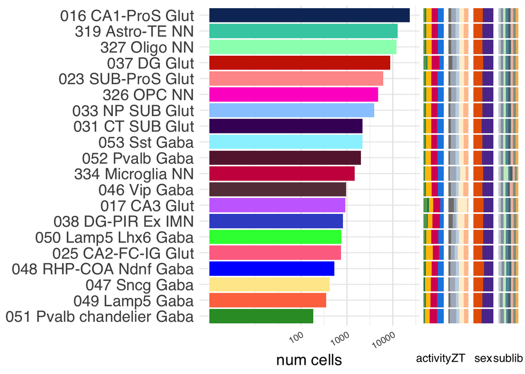

Figure 1B

```r
library(paletteer)
library(Seurat)

source("03-scripts/R/seq_functions.R")

# only load if not already in environment
if (!exists("nuclei")) {nuclei <- LoadDataset("Dec2024")}

# load colors  ----------------------------------------------------------------------
class_colors <- LoadAllenColors('class')
subclass_colors <- LoadAllenColors('subclass')
activity_colors <- LoadActivityColors()
ZT_colors <- LoadZTColors()
sex_colors <- LoadSexColors()

save_path <- "05-results/Figure1/raw_R_plots"

save_plots_if_requested <- function(plot_args_list) {
  if (!exists("SAVE_PLOTS") || !isTRUE(SAVE_PLOTS)) {
    return(invisible())
  }

  for (plot_args in plot_args_list) {
    do.call(ggsave, plot_args)
  }
}


# relevel, filter subclasses ----------------------------------------------------------------------
meta <- nuclei@meta.data

subclasses_to_use <- LoadSubclassesToUse(nuclei)

meta <- meta |>
  filter(subclass_name %in% subclasses_to_use) |>
  mutate(count = n(), .by = subclass_name) |>
  mutate(subclass_name = fct_reorder(subclass_name, count, .desc = FALSE)) |>
  select(-count)

# qc subclass ----------------------------------------------------------------------
my_theme <- theme(
  axis.title.y = element_blank(),
  axis.text.y = element_blank(),
  axis.text.x = element_text(angle=30, hjust=1),
  legend.position = 'none',
  plot.margin = margin(0, 0, 0, 0),
  panel.background = element_blank(),
  panel.grid.major.x = element_line(color = 'gray90'),
  panel.grid.minor.x = element_line(color = 'gray93'),
  panel.spacing = unit(0, "lines"),
)

# num cells
pNum <- ggplot(meta) +
  aes(y = subclass_name) +
  geom_bar(aes(fill = subclass_name)) +
  scale_fill_manual(values = subclass_colors) +
  scale_x_log10(breaks = c(100, 1000, 10000), position = 'bottom') +
  labs(x = 'num cells') +
  my_theme +
  theme(
    axis.text.y = element_text(size = 15),
    axis.title.x = element_text(size = 15),
  )

# condition ratios
pActivity <- meta |>
  group_by(subclass_name, activity_condition) |>
  summarise(n = n()) |>
ggplot() +
    aes(y = subclass_name, x = n, fill = activity_condition) +
    geom_bar(stat = 'identity', position = 'fill') +
    scale_fill_manual(values = activity_colors) +
    scale_x_continuous(breaks = NULL, position = 'bottom') +
    labs(x = 'activity') +
    my_theme

# sex ratios
pSex <- meta |>
  group_by(subclass_name, sex) |>
  summarise(n = n()) |>
ggplot() +
    aes(y = subclass_name, x = n, fill = sex) +
    geom_bar(stat = 'identity', position = 'fill') +
    scale_x_continuous(breaks = NULL, position = 'bottom') +
    scale_fill_manual(values = sex_colors) +
    labs(x = 'sex') +
    my_theme

# sublibrary ratio
pSublib <- meta |>
  group_by(subclass_name, sublibrary) |>
  summarise(n = n()) |>
ggplot() +
    aes(y = subclass_name, x = n, fill = sublibrary) +
    geom_bar(stat = 'identity', position = 'fill') +
    paletteer::scale_fill_paletteer_d("ltc::reading") +
    scale_x_continuous(breaks = NULL, position = 'bottom') +
    labs(x = 'sublib') +
    my_theme

# ZT ratio
pZT <- meta |>
  group_by(subclass_name, ZT) |>
  summarise(n = n()) |>
ggplot() +
    aes(y = subclass_name, x = n, fill = ZT) +
    geom_bar(stat = 'identity', position = 'fill') +
    scale_x_continuous(breaks = NULL, position = 'bottom') +
    scale_fill_manual(values = ZT_colors) +
    labs(x = 'ZT') +
    my_theme

# UMI plot
pUMI <- ggplot(meta) +
  aes(y = subclass_name, x = nCount_RNA) +
  geom_violin(fill = 'gray50', width = 2) +
  geom_violin(aes(fill = subclass_name), width = 2) +
  scale_fill_manual(values = subclass_colors) +
  geom_boxplot(fill = 'gray80', width = 0.3, outliers = FALSE) +
  scale_x_log10(position = 'bottom') +
  labs(x='UMI') +
  my_theme

# gene plot
pGenes <- ggplot(meta) +
  aes(y = subclass_name, x = nFeature_RNA) +
  geom_violin(aes(fill = subclass_name), width = 2) +
  scale_fill_manual(values = subclass_colors) +
  geom_boxplot(fill = 'gray80', width = 0.3, outliers = FALSE) +
  scale_x_continuous(position = 'bottom') +
  labs(x = 'genes') +
  my_theme

# pct.mt plot
pMt <- ggplot(meta) +
  aes(y = subclass_name, x = percent.mt) +
  geom_violin(aes(fill = subclass_name), width = 2) +
  scale_fill_manual(values = subclass_colors) +
  geom_boxplot(fill = 'gray80', width = 0.3, outliers = FALSE) +
  scale_x_continuous(position = 'bottom') +
  labs(y = '', x = '% mt reads') +
  my_theme

p <- pNum + pActivity + pZT + pSex + pSublib + plot_layout(widths = c(30, 3, 3, 3, 3))
print(p)
```

```r
# subclass QC for figure
save_plots_if_requested(list(
  list(
    plot = p,
    filename = 'quality_by_subclass_short.png',
    path = save_path,
    width = 15,
    height = 10,
    dpi = 300
  ),
  list(
    plot = p * LoadBarebonesTheme(ticks = 'x'),
    filename = 'quality_by_subclass_short.svg',
    path = save_path,
    width = 15,
    height = 10,
    dpi = 300
  )
))

p <- pNum + pUMI + pGenes + pMt + pActivity + pSex + pSublib + pZT +
  plot_layout(widths = c(10, 10, 10, 10, 3, 3, 3, 3, 3))
save_plots_if_requested(list(
  list(
    plot = p,
    filename = 'quality_by_subclass.png',
    path = save_path,
    width = 27,
    height = 9,
    dpi = 600
  )
))
```

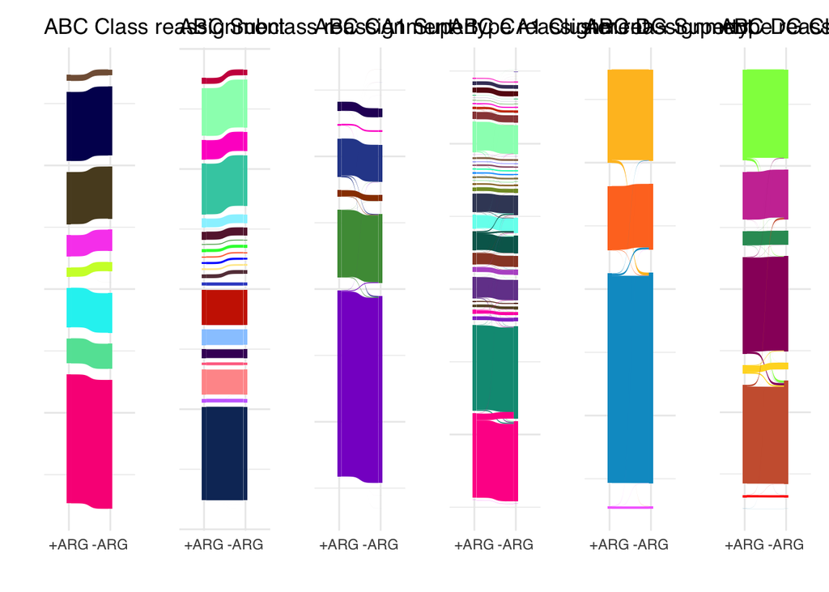

Figure 1E-H

```r
source("03-scripts/R/seq_functions.R")

library(ggsankey)
library(scCustomize)
library(reticulate)

reticulate::use_condaenv("sc")
plot_save_dir <- "05-results/Figure1/raw_R_plots"

nuclei_with <- LoadDataset("Dec2024")

class_colors <- LoadAllenColors('class')
subclass_colors <- LoadAllenColors('subclass')
supertype_colors <- LoadAllenColors('supertype')
cluster_colors <- LoadAllenColors('cluster')

# 1. Run Dec2024 with ARGs through MapMyCells.
      # already done

# 2. Remove ARGs from Seurat object.
gene_list_to_rm <- unique(c(LoadGeneList('tyssowski'), LoadGeneList('IEG')))
features_with <- Features(nuclei_with)
features_without <- features_with[!features_with %in% gene_list_to_rm]

# use DietSeurat to get just the RNA assay, which we will then subset
DefaultAssay(nuclei_with) <- 'RNA'
nuclei_without <- DietSeurat(nuclei_with,
                             assays = 'RNA',
                             layers = 'counts',
                             features = features_without)

# Run Dec2024 without ARGs through MapMyCells ----
working_save_dir <- "04-analysis/cluster_reassignment"
# as.anndata(x = nuclei_without, file_path = working_save_dir, file_name = "Dec2024_withoutARGs", main_layer = "counts", other_layers = NULL)


# merge with and without metadata ----
meta_mapmycells <- read_csv("04-analysis/cluster_reassignment/Dec2024_withoutARGs_10xWholeMouseBrain(CCN20230722)_HierarchicalMapping_UTC_1738267008578/Dec2024_withoutARGs_10xWholeMouseBrain(CCN20230722)_HierarchicalMapping_UTC_1738267008578.csv", skip = 4)

meta_merge <- nuclei_with@meta.data |>
      left_join(meta_mapmycells,
                by = c('barcode' = 'cell_id'),
                suffix = c('.with', '.without'),
                relationship = 'one-to-one',
                unmatched = 'error'
                )

# make some new vars
subclasses_to_use <- LoadSubclassesToUse(nuclei_with)
meta <- meta_merge |>
      mutate(class_bootstrapping_probability_diff = class_bootstrapping_probability.with - class_bootstrapping_probability.without) |>
      mutate(subclass_bootstrapping_probability_diff = subclass_bootstrapping_probability.with - subclass_bootstrapping_probability.without) |>
      mutate(supertype_bootstrapping_probability_diff = supertype_bootstrapping_probability.with - supertype_bootstrapping_probability.without) |>
      mutate(cluster_bootstrapping_probability_diff = cluster_bootstrapping_probability.with - cluster_bootstrapping_probability.without) |>
      filter(subclass_name.with %in% subclasses_to_use) |>
      select(-starts_with('emptyDrops_'))


# sankeys ----------------------------------------
plots <- list()

# class
p1 <- meta |>
  make_long(class_name.with, class_name.without) |>
  mutate(x = fct_recode(
    x,
    "+ARG" = "class_name.with",
    "-ARG" = "class_name.without",
  )) |>
  mutate(next_x = fct_recode(
    next_x,
    "-ARG" = "class_name.without"
  )) |>
ggplot() +
  aes(x = x, next_x = next_x, node = node, next_node = next_node,
      fill = node) +
  geom_sankey() +
  scale_fill_manual(values = class_colors) +
  theme(
    legend.position = 'none',
    axis.text.y = element_blank()
    ) +
  labs(
    title = 'ABC Class reassignment',
    x = '',
    y = ''
  )
# print(p1)
plots <- c(plots, list(p1))

if (exists("SAVE_PLOTS") & SAVE_PLOTS==TRUE){
    ggsave(plot = p,
          filename = 'reassignment_sankey_class.png',
          path = plot_save_dir,
          width = 4, height = 8, dpi = 900)
    svgsave(plot = p + LoadBarebonesTheme(),
          filename = 'reassignment__sankey_class.svg',
          path = plot_save_dir,
          width = 4, height = 8)
}

# subclass
p2 <- meta |>
  make_long(subclass_name.with, subclass_name.without) |>
  mutate(x = fct_recode(
    x,
    "+ARG" = "subclass_name.with",
    "-ARG" = "subclass_name.without",
  )) |>
  mutate(next_x = fct_recode(
    next_x,
    "-ARG" = "subclass_name.without"
  )) |>
ggplot() +
  aes(x = x, next_x = next_x, node = node, next_node = next_node,
      fill = node) +
  geom_sankey() +
  scale_fill_manual(values = subclass_colors) +
  theme(
    legend.position = 'none',
    axis.text.y = element_blank()
    ) +
  labs(
    title = 'ABC Subclass reassignment',
    x = '',
    y = ''
  )
# print(p2)
plots <- c(plots, list(p2))

if (exists("SAVE_PLOTS") & SAVE_PLOTS==TRUE){
    ggsave(plot = p,
          filename = 'reassignment_sankey_subclass.png',
          path = plot_save_dir,
          width = 4, height = 8, dpi = 900)
    svgsave(plot = p + LoadBarebonesTheme(),
          filename = 'reassignment__sankey_subclass.svg',
          path = plot_save_dir,
          width = 4, height = 8)
}

subclass_list <- list(
  CA1 = '016 CA1-ProS Glut',
  DG  = '037 DG Glut'
)

for (celltype in names(subclass_list)) {
  # supertype sankey
  p <- meta |>
    filter(subclass_name.with == subclass_list[[celltype]]) |>
    make_long(supertype_name.with, supertype_name.without) |>
    mutate(x = fct_recode(
      x,
      "+ARG" = "supertype_name.with",
      "-ARG" = "supertype_name.without",
    )) |>
    mutate(next_x = fct_recode(
      next_x,
      "-ARG" = "supertype_name.without"
    )) |>
  ggplot() +
    aes(x = x, next_x = next_x, node = node, next_node = next_node,
        fill = node) +
    geom_sankey() +
    scale_fill_manual(values = supertype_colors) +
    theme(
      legend.position = 'none',
      axis.text.y = element_blank()
      ) +
    labs(
      title = glue('ABC {celltype} Supertype reassignment'),
      x = '',
      y = ''
    )
  plots <- c(plots, list(p))

  if (exists("SAVE_PLOTS") & SAVE_PLOTS==TRUE){
      ggsave(plot = p,
            filename = glue('reassignment_sankey_supertype_{celltype}.png'),
            path = plot_save_dir,
            width = 4, height = 8, dpi = 900)
      svgsave(plot = p + LoadBarebonesTheme(),
            filename = glue('reassignment__sankey_supertype_{celltype}.svg'),
            path = plot_save_dir,
          width = 4, height = 8)
  }

  # cluster
  p <- meta |>
    filter(subclass_name.with == subclass_list[[celltype]]) |>
    make_long(cluster_name.with, cluster_name.without) |>
    mutate(x = fct_recode(
      x,
      "+ARG" = "cluster_name.with",
      "-ARG" = "cluster_name.without",
    )) |>
    mutate(next_x = fct_recode(
      next_x,
      "-ARG" = "cluster_name.without"
    )) |>
  ggplot() +
    aes(x = x, next_x = next_x, node = node, next_node = next_node,
        fill = node) +
    geom_sankey() +
    scale_fill_manual(values = cluster_colors) +
    theme(
      legend.position = 'none',
      axis.text.y = element_blank()
      ) +
    labs(
      title = glue('ABC {celltype} Cluster reassignment'),
      x = '',
      y = ''
    )
  # print(p)
  plots <- c(plots, list(p))

  if (exists("SAVE_PLOTS") & SAVE_PLOTS==TRUE){
      ggsave(plot = p,
            filename = glue('reassignment_sankey_cluster_{celltype}.png'),
            path = plot_save_dir,
            width = 4, height = 8, dpi = 900)
      svgsave(plot = p + LoadBarebonesTheme(),
            filename = glue('reassignment__sankey_cluster_{celltype}.svg'),
            path = plot_save_dir,
            width = 4, height = 8)
  }
}

# put all plots in list using plot_layout
combined <- Reduce(`+`, plots)
combined + plot_layout(nrow=1)
```

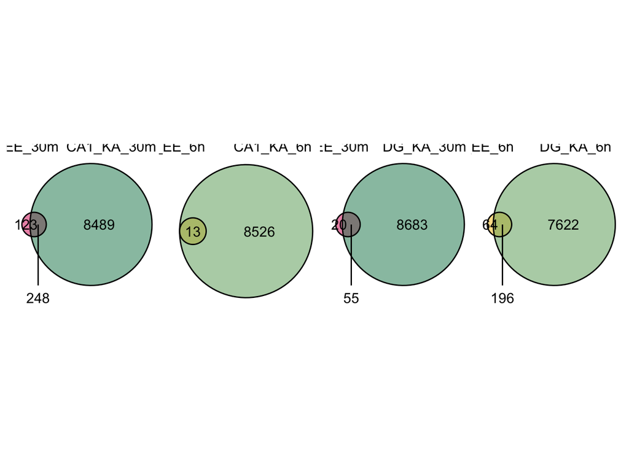

Figure 2A-B

```r
# Make venn diagrams for DEGs at 30m and 6h in both CA1 and DG
source('03-scripts/R/seq_functions.R')

library(ggvenn)

# load data --------------------------------
deg_sets <- list(
  CA1_EE_30m = read_csv("04-analysis/DEGs/Dec2024_activity_condition_pseudobulk/016_CA1-ProS_Glut__EE30m_vs_SE.csv"),
  CA1_EE_6h  = read_csv("04-analysis/DEGs/Dec2024_activity_condition_pseudobulk/016_CA1-ProS_Glut__EE6h_vs_SE.csv"),
  CA1_KA_30m = read_csv("04-analysis/DEGs/Dec2024_activity_condition_pseudobulk/016_CA1-ProS_Glut__KA30m_vs_SE.csv"),
  CA1_KA_6h  = read_csv("04-analysis/DEGs/Dec2024_activity_condition_pseudobulk/016_CA1-ProS_Glut__KA6h_vs_SE.csv"),
  DG_EE_30m = read_csv("04-analysis/DEGs/Dec2024_activity_condition_pseudobulk/037_DG_Glut__EE30m_vs_SE.csv"),
  DG_EE_6h  = read_csv("04-analysis/DEGs/Dec2024_activity_condition_pseudobulk/037_DG_Glut__EE6h_vs_SE.csv"),
  DG_KA_30m = read_csv("04-analysis/DEGs/Dec2024_activity_condition_pseudobulk/037_DG_Glut__KA30m_vs_SE.csv"),
  DG_KA_6h  = read_csv("04-analysis/DEGs/Dec2024_activity_condition_pseudobulk/037_DG_Glut__KA6h_vs_SE.csv")
)

# pull just the gene column for DEGs from each item in list
deg_sets <- lapply(deg_sets,
       function(df)
         df |>
         filter(padj < 0.05 & abs(log2FoldChange.raw) > 0.585) |>
         pull(gene)
       )


# make venn diagrams --------------------------------
# CA1 30m
CA1_30m <- ggvenn(
  deg_sets[c("CA1_EE_30m", "CA1_KA_30m")],
  fill_color = c("#D81B60", "#098154FF"),
  auto_scale = T,
  stroke_size = 0.5,
  set_name_size = 4,
  show_percentage = FALSE
) +
  theme(legend.position = "none")

# DG 30m
DG_30m <- ggvenn(
  deg_sets[c("DG_EE_30m", "DG_KA_30m")],
  fill_color = c("#D81B60", "#098154FF"),
  auto_scale = T,
  stroke_size = 0.5,
  set_name_size = 4,
  show_percentage = FALSE
) +
  theme(legend.position = "none")

# CA1 6h
CA1_6h <- ggvenn(
  deg_sets[c("CA1_EE_6h", "CA1_KA_6h")],
  fill_color = c("#FFC107", "#63a45e"),
  auto_scale = T,
  stroke_size = 0.5,
  set_name_size = 4,
  show_percentage = FALSE
) +
  theme(legend.position = "none")

# DG 6h
DG_6h <- ggvenn(
  deg_sets[c("DG_EE_6h", "DG_KA_6h")],
  fill_color = c("#FFC107", "#63a45e"),
  auto_scale = T,
  stroke_size = 0.5,
  set_name_size = 4,
  show_percentage = FALSE
) +
  theme(legend.position = "none")

p1 <- CA1_30m + CA1_6h + DG_30m + DG_6h + plot_layout(nrow=1)
print(p1)
```

```r
# save plots
if (exists("SAVE_PLOTS") & SAVE_PLOTS==TRUE) {
save_dir <- "05-results/Figure2/raw_R_plots"
# png
ggsave(plot = CA1_30m,
       filename = "venn__CA1_30m.png",
       width = 4, height = 4,
       path = save_dir)
ggsave(plot = CA1_6h,
       filename = "venn__CA1_6h.png",
       width = 4, height = 4,
       path = save_dir)
ggsave(plot = DG_30m,
       filename = "venn__DG_30m.png",
       width = 4, height = 4,
       path = save_dir)
ggsave(plot = DG_6h,
       filename = "venn__DG_6h.png",
       width = 4, height = 4,
       path = save_dir)
# svg
ggsave(plot = CA1_30m,
       filename = "venn_CA1_30m.svg",
       width = 4, height = 4,
       path = save_dir)
ggsave(plot = CA1_6h,
       filename = "venn_CA1_6h.svg",
       width = 4, height = 4,
       path = save_dir)
ggsave(plot = DG_30m,
       filename = "venn_DG_30m.svg",
       width = 4, height = 4,
       path = save_dir)
ggsave(plot = DG_6h,
       filename = "venn_DG_6h.svg",
       width = 4, height = 4,
       path = save_dir)
}
  ## ----
```

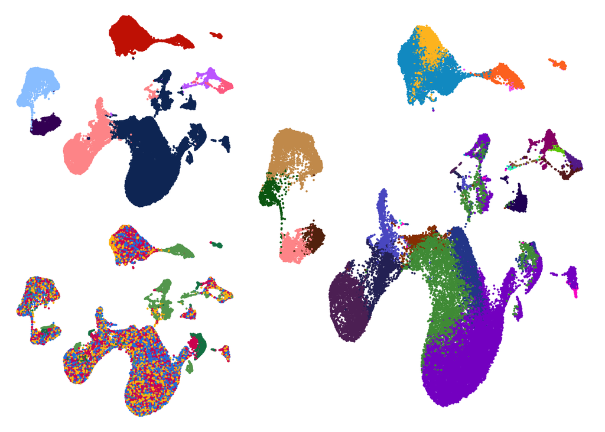

Figure 2C-E

```r
# This script plots UMAPs for each gigaclass, colored by activity_condition, subclass, and supertype.
# It also plots, for each subclass, the supertype distribution in each activity_condition.
source('03-scripts/R/seq_functions.R')

library(ggbreak)

save_dir <- '05-results/Figure2/raw_R_plots/'
if (!exists('nuclei')) {
  nuclei <- LoadDataset('Dec2024')
}
seurat_subsets <- LoadDataset('Dec2024', as_gigaclasses = T)

activity_colors <- LoadActivityColors()
subclass_colors <- LoadAllenColors('subclass')
supertype_colors <- LoadAllenColors('supertype')
cluster_colors <- LoadAllenColors('cluster')

# gigaclass UMAPs ------------------------------------------------
# remove low-N subclasses
subclass_sets <- LoadSubclassesToUse(nuclei, as_gigaclasses = TRUE)
subclass_sets$excitatory <- subclass_sets$excitatory[-2] # rm CA2

# re-embed nuclei
nuclei_gigaclass <- seurat_subsets[['excitatory']] |>
  RunUMAP(dims = 1:41, seed.use = 17)
p1 <- DimPlot(nuclei_gigaclass, group.by = 'subclass_name', shuffle = T, seed = 17) +
  scale_color_manual(values = subclass_colors) +
  theme_void() +
  theme(legend.position = 'none',
        # panel.border = element_rect(color = "black", fill = NA, linewidth = 1),
        plot.title = element_blank())
p2 <- DimPlot(nuclei_gigaclass, group.by = 'activity_condition', shuffle = T, seed = 17) +
  scale_color_manual(values = activity_colors) +
  theme_void() +
  theme(legend.position = 'none',
        # panel.border = element_rect(color = "black", fill = NA, linewidth = 1),
        plot.title = element_blank())
p3 <- DimPlot(nuclei_gigaclass, group.by = 'supertype_name', shuffle = T, seed = 17) +
  scale_color_manual(values = supertype_colors) +
  theme_void() +
  theme(legend.position = 'none',
        # panel.border = element_rect(color = "black", fill = NA, linewidth = 1),
        plot.title = element_blank())

design <- "
133
233
"
p_UMAPs <- p1+p2+p3 + plot_layout(design = design, widths = c(1,0.75,0.75))
# print(p_UMAPs)

if (SAVE_PLOTS) {
  # png
  ggsave(plot = p_UMAPs,
          filename = glue('reembedded_UMAPs_{gigaclass}.png'),
          path = save_dir,
          width = 15, height = 10, dpi = 300, bg = 'white')
  # svg
  ggsave(plot = p_UMAPs,
          filename = glue('reembedded_UMAPs_{gigaclass}.svg'),
          path = save_dir,
          width = 15, height = 10, bg = 'transparent')

}


# make df_cluster_counts ------------------------------------------------
df_cluster_counts <- nuclei@meta.data |>
  filter(subclass_name %in% LoadSubclassesToUse(nuclei)) |>
  group_by(activity_condition, subclass_name, supertype_name) |>
  dplyr::count(cluster_name, name = 'cluster_count') |>
  group_by(activity_condition, subclass_name)


# supertype by condition ------------------------------------------------
# excitatory
p1 <- df_cluster_counts |>
  filter(subclass_name %in% subclass_sets$excitatory) |>
  group_by(activity_condition, subclass_name, supertype_name) |>
  summarize(supertype_count = sum(cluster_count)) |>
ggplot() +
  aes(x = activity_condition, y = supertype_count, fill = supertype_name) +
  geom_bar(stat = "identity", position = 'fill', linewidth = 1) +
  scale_fill_manual(values = supertype_colors) +
  labs(x = '', y = 'Supertype proportion') +
  facet_wrap(~subclass_name, nrow = 1) +
  theme(
    axis.text.x = element_text(angle=30,hjust=1),
    legend.position = 'none'
  )
# print(p1)
p_UMAPs
```

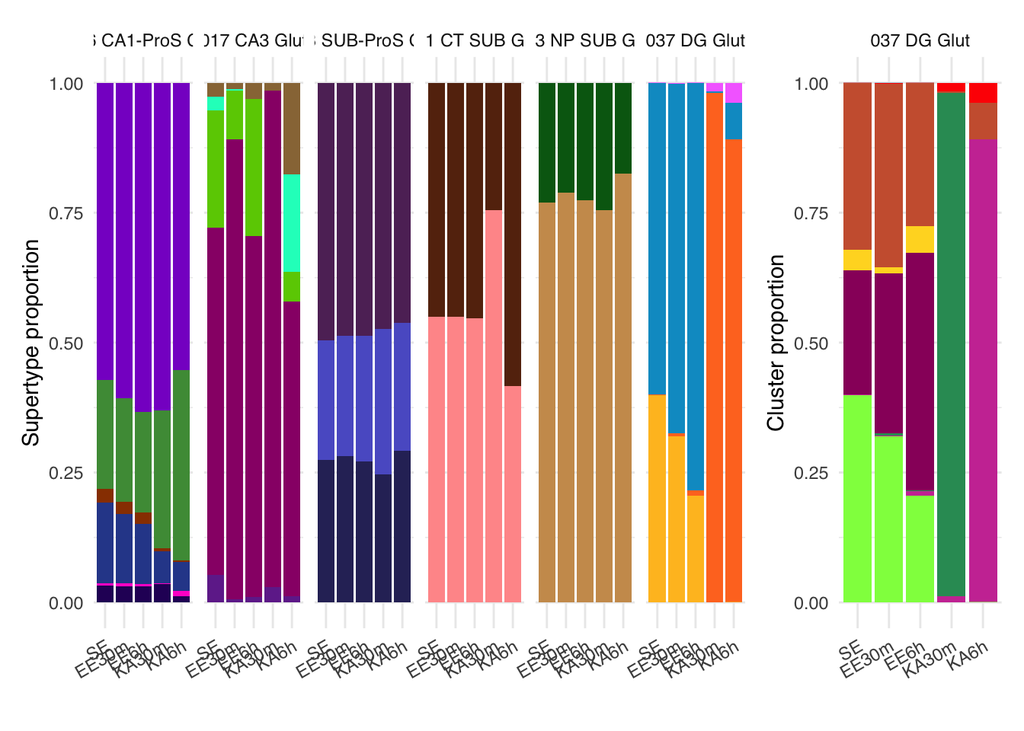

Figure 2C-E

```r
# cluster by condition ------------------------------------------------
# excitatory
p2 <- df_cluster_counts |>
  filter(subclass_name == '037 DG Glut') |>
ggplot() +
  aes(x = activity_condition, y = cluster_count, fill = cluster_name) +
  geom_bar(stat = "identity", position = 'fill', linewidth = 1) +
  facet_wrap(~subclass_name, nrow = 1) +
  scale_fill_manual(values = cluster_colors) +
  labs(x = '', y = 'Cluster proportion') +
  theme(
    legend.position = 'none',
    axis.text.x = element_text(angle=30,hjust=1),)
# print(p2)

p1 + p2 + plot_layout(nrow = 1, widths = c(4,1))
```

```r
# save ----------------------------------------
if (SAVE_PLOTS) {
  # png
  ggsave(plot = p1,
         filename = 'excitatory_supertype_by_condition.png',
         path = save_dir,
         width = 15, height = 10, dpi = 300, bg = 'white')
  ggsave(plot = p2,
         filename = 'excitatory_cluster_by_condition.png',
         path = save_dir,
         width = 15, height = 10, dpi = 300, bg = 'white')
  ggsave(plot = p3,
         filename = 'DG_Glut3_cluster_by_condition.png',
         path = save_dir,
         width = 15, height = 10, dpi = 300, bg = 'white')
  # svg
  ggsave(plot = p1 + LoadBarebonesTheme(ticks = 'y'),
         filename = 'excitatory_supertype_by_condition.svg',
         path = save_dir,
         width = 15, height = 10, bg = 'transparent')
  ggsave(plot = p2 + LoadBarebonesTheme(ticks = 'y'),
         filename = 'excitatory_cluster_by_condition.svg',
         path = save_dir,
         width = 15, height = 10, bg = 'transparent')
  ggsave(plot = p3 + LoadBarebonesTheme(ticks = 'y'),
         filename = 'DG_Glut3_cluster_by_condition.svg',
         path = save_dir,
         width = 15, height = 10, bg = 'transparent')

}
```

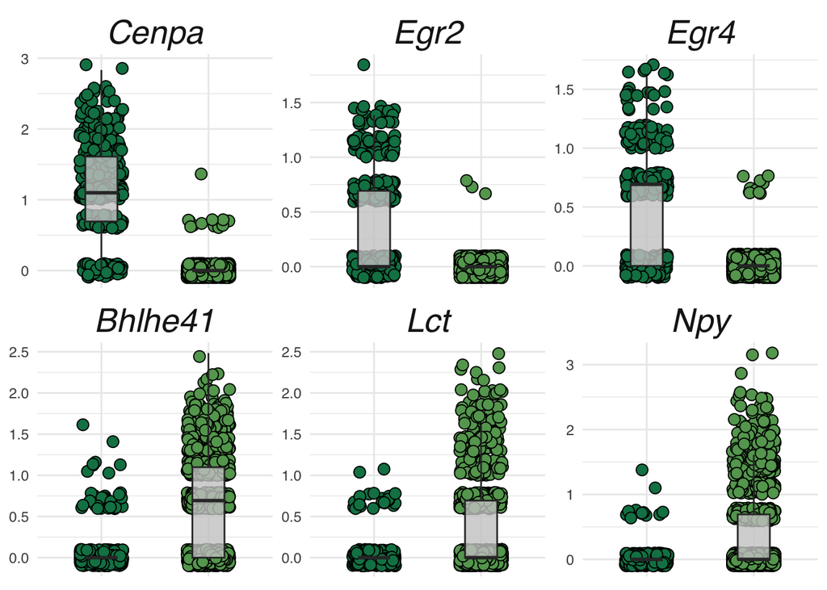

Figure 2F-G

```r
# This script will plot the expression of marker genes for dentate supertypes
# in different activity conditions.
source('03-scripts/R/seq_functions.R')

if (!exists('nuclei')) {nuclei <- LoadDataset('Dec2024')}

activity_colors  <- LoadActivityColors()
subclass_colors  <- LoadAllenColors('subclass')
supertype_colors <- LoadAllenColors('supertype')
cluster_colors   <- LoadAllenColors('cluster')


# get marker genes ------------------------------------------------
supertype_sheet <- read_excel("02-data/published_data/Yao2023/allen_taxonomy_metadata.xlsx",
                  sheet = "supertype_annotation")
cluster_sheet <- read_excel("02-data/published_data/Yao2023/allen_taxonomy_metadata.xlsx",
                  sheet = "cluster_annotation")
supertype_genes_DG <- supertype_sheet |>
  slice(136:139) |>
  select(contains('markers.combo')) |>
  pivot_longer(cols = everything(), values_to = 'gene', names_to = NULL) |>
  separate_rows(gene, sep = ",") |>
  distinct(gene) |>
  pull(gene)

cluster_genes_DG <- cluster_sheet |>
  slice(502:510) |>
  select(contains('markers.combo')) |>
  pivot_longer(cols = everything(), values_to = 'gene', names_to = NULL) |>
  separate_rows(gene, sep = ",") |>
  distinct(gene) |>
  pull(gene)


# df expression ---------------------------------------------
nuclei_DG <- nuclei |> subset(subclass_name == '037 DG Glut')

mat <- GetAssayData(nuclei_DG, assay = 'SCT', layer = 'data')
all_marker_genes <- unique(c(supertype_genes_DG, cluster_genes_DG))
# print(glue("{all_marker_genes[which(!all_marker_genes %in% rownames(mat))]} not in object"))
all_marker_genes <- all_marker_genes[which(all_marker_genes %in% rownames(mat))]

mat <- mat[all_marker_genes,] |> t()
df <- data.frame(mat) |>
  rownames_to_column(var = 'barcode') |>
  as_tibble() |>
  left_join(nuclei_DG@meta.data) |>
  pivot_longer(cols = any_of(all_marker_genes), names_to = 'gene', values_to = 'expression') |>
  relocate(gene, expression, .after = barcode)

# critical cluster-assignment genes
critical_genes <- c('Cenpa', 'Egr2', 'Egr4', # for cluster 0508
                    'Bhlhe41', 'Lct', 'Npy') # for cluster 0509

                    # activity_condition
p1 <- df |>
  filter(gene %in% critical_genes) |>
  mutate(gene = factor(gene, levels = critical_genes)) |>
  filter(str_detect(activity_condition, '^KA')) |>
ggplot() +
  aes(x = activity_condition, y = expression, fill = activity_condition) +
  geom_jitter(size = 3, width = 0.2, height = 0.1, shape = 21, alpha = 1, set.seed(17)) +
  # geom_jitter(width = 0.4, height = 0.1, shape = 21, size = 5, set.seed(17)) +
  geom_boxplot(width = 0.3, alpha = 0.8, outlier.shape = NA, fill = 'gray80') +
  facet_wrap(~gene, scales = 'free_y') +
  scale_fill_manual(values = activity_colors) +
  theme(
    legend.position = 'none',
    strip.text = element_text(size = 20, face = 'italic'),
    axis.title = element_blank(),
    axis.text.x = element_blank(),
  )
print(p1)
```

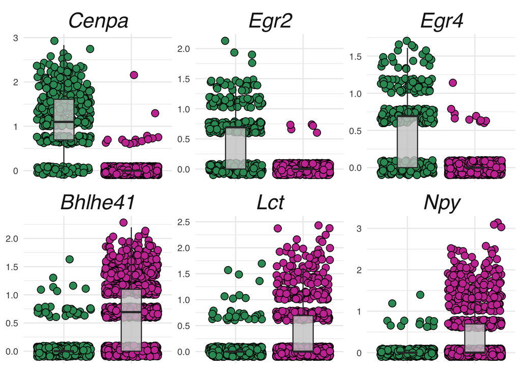

Figure 2F-G

```r
if (exists('SAVE_PLOTS') & SAVE_PLOTS==TRUE) {
  ggsave(filename = 'critical__genes_activity.png',
        path = '05-results/Figure2/raw_R_plots',
        width = 8, height = 4, dpi = 900)
  ggsave(filename = 'critical_genes_activity.svg',
        plot = p1 + LoadBarebonesTheme(ticks = 'y'),
        path = '05-results/Figure2/raw_R_plots',
        width = 8, height = 4, dpi = 900)
}

# supertype
p2 <- df |>
  filter(gene %in% critical_genes) |>
  mutate(gene = factor(gene, levels = critical_genes)) |>
  filter(str_detect(cluster_name, '0508|0509')) |>
ggplot() +
  aes(x = cluster_name, y = expression, fill = cluster_name) +
  geom_jitter(size = 3, width = 0.4, height = 0.1, shape = 21, alpha = 1, set.seed(17)) +
  # geom_jitter(width = 0.4, height = 0.1, shape = 21, size = 5, set.seed(17)) +
  geom_boxplot(width = 0.3, alpha = 0.8, outlier.shape = NA, fill = 'gray80') +
  facet_wrap(~gene, scales = 'free_y') +
  scale_fill_manual(values = cluster_colors) +
  theme(
    legend.position = 'none',
    strip.text = element_text(size = 20, face = 'italic'),
    axis.title = element_blank(),
    axis.text.x = element_blank(),
  )
print(p2)
```

```r
if (exists('SAVE_PLOTS') & SAVE_PLOTS==TRUE) {
ggsave(filename = 'critical__genes_cluster.png',
       path = '05-results/Figure2/raw_R_plots',
       width = 8, height = 4, dpi = 900)
ggsave(filename = 'critical_genes_cluster.svg',
       plot = p2 + LoadBarebonesTheme(ticks = 'y'),
       path = '05-results/Figure2/raw_R_plots',
       width = 8, height = 4)
}
```